# Lorauna Report

Janik von Rotz

4/16/2019

This document provides insight about data gathered by the lorauna app. During the 2018/2019 sauna season the entrering and exiting visitors have been continiously logged by the on-premise receptionist This log entries are now used to analyze the seasons performance.

# Data

The dataset to create this report is pulled directly from the lorauna database and has been prepared in the following manner:

```r
# setup connection
connection <- mongo(collection = "visitor", db = "lorauna", url = Sys.getenv("MONGO_URL"))

# read and filter visitors data
visitors <- connection$find(
  query = '{
    "created": { "$gte" : { "$date" : "2018-11-01T00:00:00Z" }},
    "created": { "$lte" : { "$date" : "2019-03-31T00:00:00Z" }}
  }'
)

# add date column
visitors$date <- as.Date(visitors$created)

# add day column
visitors$day <- format(visitors$date, '%d')

# add week day column
visitors$weekday <- weekdays(as.Date(visitors$date))

# add month column
visitors$month <- months(as.Date(visitors$date))

# filter weekdays
visitors <- visitors %>% filter(weekday %in% c('Monday', 'Tuesday', 'Friday', 'Saturday', 'Sunday'))

# define weekday factors for sorting
visitors$weekday <- factor(visitors$weekday, levels=c("Monday",
    "Tuesday", "Wednesday", "Thursday", "Friday", "Saturday", "Sunday"))

# define month factors for sorting
visitors$month <- factor(visitors$month, levels=c("November", "December", "January", "February", "March"))

# filter incoming visitors
visitors_in <- visitors %>% filter(value == 1)
```

Summary of the dataset:

```r
summary(visitors_in)
```

```
##      value     sauna_id            created
##  Min.   :1   Length:3608        Min.   :2018-11-02 22:51:32
##  1st Qu.:1   Class :character   1st Qu.:2018-12-07 16:49:59
##  Median :1   Mode  :character   Median :2019-01-25 17:35:36
##  Mean   :1                      Mean   :2019-01-18 20:25:40
##  3rd Qu.:1                      3rd Qu.:2019-02-26 18:47:36
##  Max.   :1                      Max.   :2019-03-30 19:53:55
##
##  current_seats        date                day                 weekday
##  Min.   :-2.00   Min.   :2018-11-02   Length:3608        Monday   :569
##  1st Qu.: 8.00   1st Qu.:2018-12-07   Class :character   Tuesday  :638
##  Median :15.00   Median :2019-01-25   Mode  :character   Wednesday:  0
##  Mean   :14.51   Mean   :2019-01-18                      Thursday :  0
##  3rd Qu.:21.00   3rd Qu.:2019-02-26                      Friday   :678
##  Max.   :33.00   Max.   :2019-03-30                      Saturday :813
##                                                          Sunday   :910
##       month
##  November:740
##  December:583
##  January :611
##  February:784
##  March   :890
##
##
```

# Summary by Month

Sum of visitors for each month:

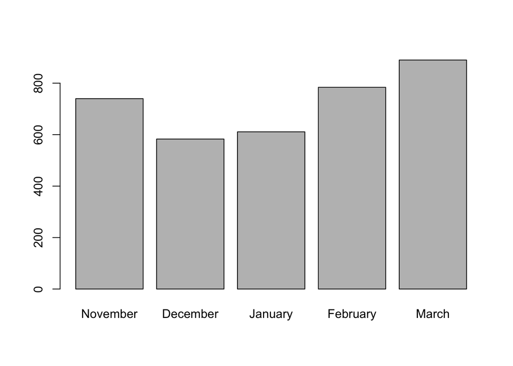

## November

In November there were **740** visitors.

The following bar plot shows the average distribution by weekday:

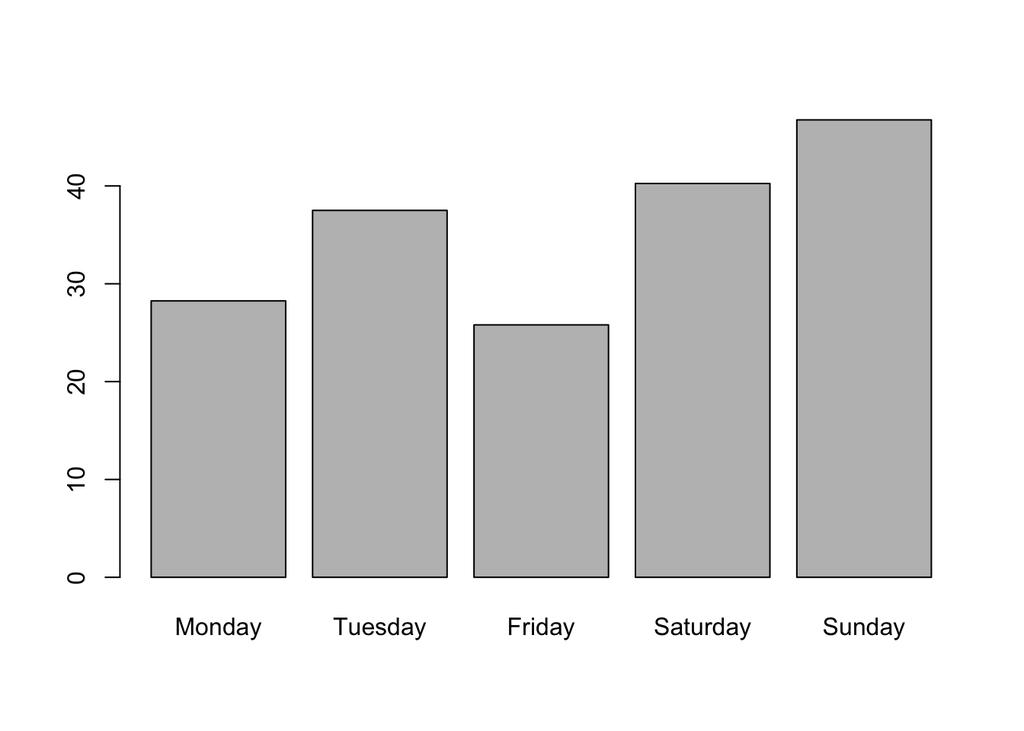

## December

In December there were **583** visitors.

The following bar plot shows the average distribution by weekday:

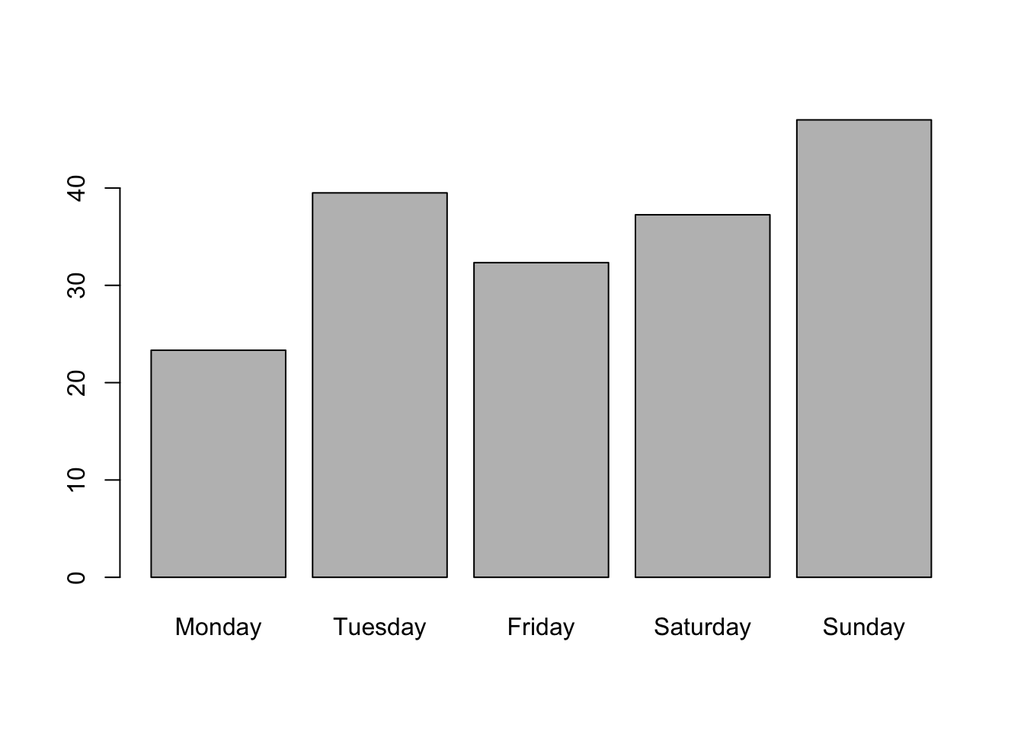

## January

In January there were **611** visitors.

The following bar plot shows the average distribution by weekday:

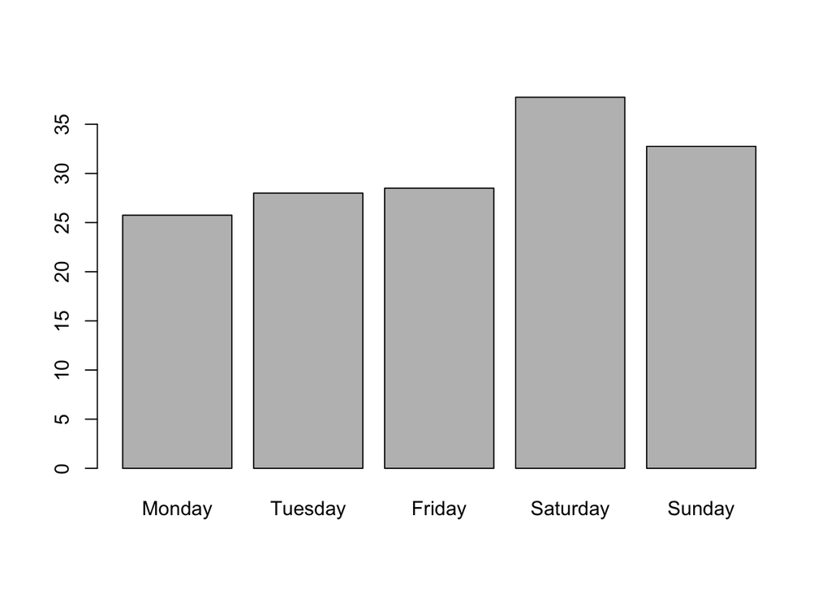

## February

In February there were **784** visitors.

The following bar plot shows the average distribution by weekday:

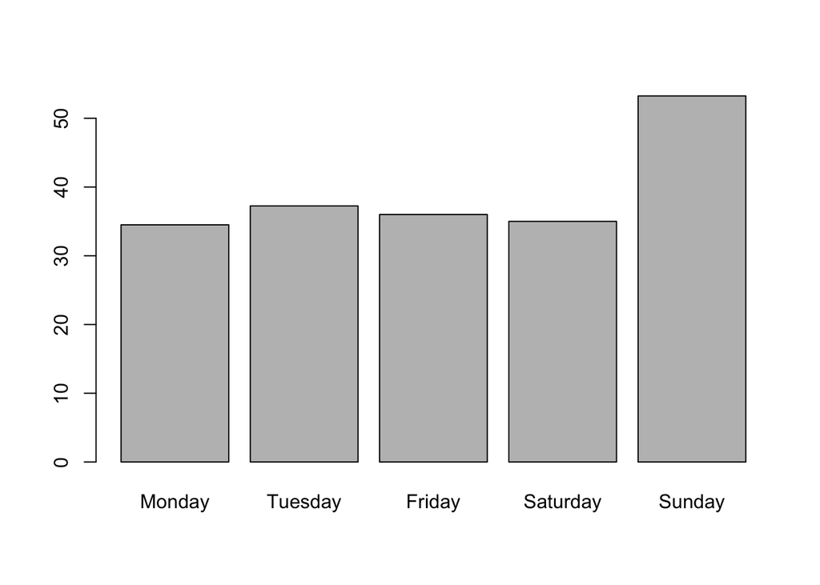

## March

In March there were **890** visitors.

The following bar plot shows the average distribution by weekday:

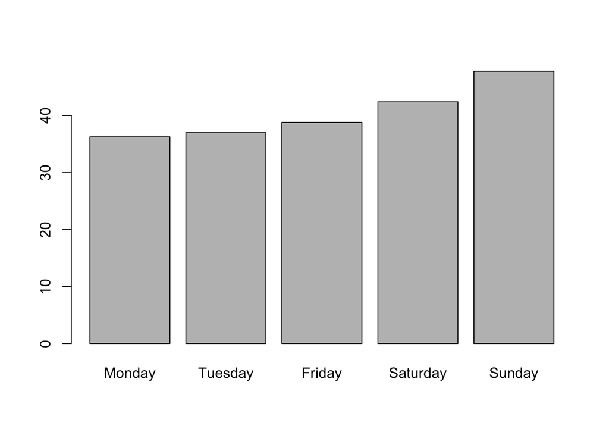

# Source

The source code for creating this report has been published to [Github - janikvonrotz/lorauna-stats](https://github.com/janikvonrotz/lorauna-stats).